# Finding optimal clustering parameters

We currently implement four algorithms for clustering the BANKSY matrix with *ClusterBanksy*: Leiden (default), Louvain, k-means, and model based clustering. Here, we demonstrate how to perform a grid search of parameters for Leiden clustering. See `?ClusterBanksy` for more details on the parameters for different clustering methods.

## Parameters

The `lambda` parameter is a mixing parameter $\in[0,1]$ which determines how much spatial information is incorporated for clustering. Larger values incorporate more spatial information. Let the gene-cell matrix be $G_O$ and the neighbour feature-cell matrix be $G_N$. The joint matrix used for clustering is the (row) concatenation of $\sqrt{1-\lambda}\;G_O$ and $\sqrt{\lambda}\;G_N$.

`k.neighbours` is the number of k nearest neighbors used to construct the shared nearest neighbors network. `resolution` is the resolution used in Leiden clustering. Higher resolutions yield more clusters.

We first set up the data for clustering:

```r
library(Banksy)
library(ggplot2)
library(gridExtra)

data("hippocampus")
expr <- hippocampus$expression
locs <- hippocampus$locations
bank <- BanksyObject(own.expr = expr, cell.locs = locs)
bank <- NormalizeBanksy(bank)
bank <- ComputeBanksy(bank)
bank <- ScaleBanksy(bank)
bank <- RunPCA(bank, lambda = c(0, 0.3), npcs = 20)
```

## Grid search

Define a parameter space. We explore different combinations of `lambda` and `resolution`, fixing `kneighbours`:

```r
lam <- c(0, 0.3)
res <- c(0.8, 1.2)
knbr <- 50

set.seed(42)
bank <- ClusterBanksy(bank, lambda = lam, resolution = res, k.neighbors = knbr, npcs = 20)
```

```
#> Iteration 1 out of 4
#> Iteration 2 out of 4
#> Iteration 3 out of 4
#> Iteration 4 out of 4
```

This populates the `meta.data` slot of the *BanksyObject* with cluster labels for each combination of parameters:

```r
head(meta.data(bank))
```

```
#>      cell_ID clust_lam0_k50_res0.8 clust_lam0_k50_res1.2
#> 1 cellID_110                     2                     6
#> 2 cellID_124                     3                     2
#> 3 cellID_128                     2                     7
#> 4 cellID_150                     2                     6
#> 5 cellID_160                     1                     1
#> 6 cellID_166                     7                    11
#>   clust_lam0.3_k50_res0.8 clust_lam0.3_k50_res1.2
#> 1                       9                       9
#> 2                       1                      11
#> 3                       6                       6
#> 4                       9                       9
#> 5                       8                       7
#> 6                       7                      12
```

## Cluster similarity

To compare clustering labels from different parameter combinations, the package implements the *getARI* and *plotARI* functions. These compute the adjusted Rand index (ARI) for all pairs of clusters to assess the similarity of clustering labels.

```r
getARI(bank)
```

```
#>                         clust_lam0_k50_res0.8 clust_lam0_k50_res1.2
#> clust_lam0_k50_res0.8                   1.000                 0.836
#> clust_lam0_k50_res1.2                   0.836                 1.000
#> clust_lam0.3_k50_res0.8                 0.549                 0.581
#> clust_lam0.3_k50_res1.2                 0.520                 0.554
#>                         clust_lam0.3_k50_res0.8 clust_lam0.3_k50_res1.2
#> clust_lam0_k50_res0.8                     0.549                   0.520
#> clust_lam0_k50_res1.2                     0.581                   0.554
#> clust_lam0.3_k50_res0.8                   1.000                   0.862
#> clust_lam0.3_k50_res1.2                   0.862                   1.000
```

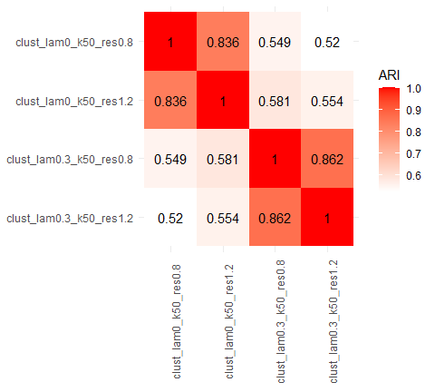

```r
plotARI(bank)
```

## Connecting clusters

To visually compare between clusters obtained with different combination of parameters (a parameter run), the package implements *ConnectClusters* which performs a mapping to harmonise cluster labels between different parameter runs.

```r
bank <- ConnectClusters(bank, map.to = 'clust_lam0.3_k50_res1.2')

head(meta.data(bank))
```

```
#>      cell_ID clust_lam0_k50_res0.8 clust_lam0_k50_res1.2
#> 1 cellID_110                     6                    10
#> 2 cellID_124                     5                     5
#> 3 cellID_128                     6                     6
#> 4 cellID_150                     6                    10
#> 5 cellID_160                     1                     1
#> 6 cellID_166                    12                     8
#>   clust_lam0.3_k50_res0.8 clust_lam0.3_k50_res1.2
#> 1                       9                       9
#> 2                       5                      11
#> 3                       6                       6
#> 4                       9                       9
#> 5                       7                       7
#> 6                      12                      12
```

This updates the `meta.data` slot with new cluster labels that can be used for visualisation. We can visualise connected output as follows.

First, obtain cluster names:

```r
mdnames <- names(meta.data(bank))
clustnames <- mdnames[grep('^clust', mdnames)]
```

Then, visualise the cluster runs:

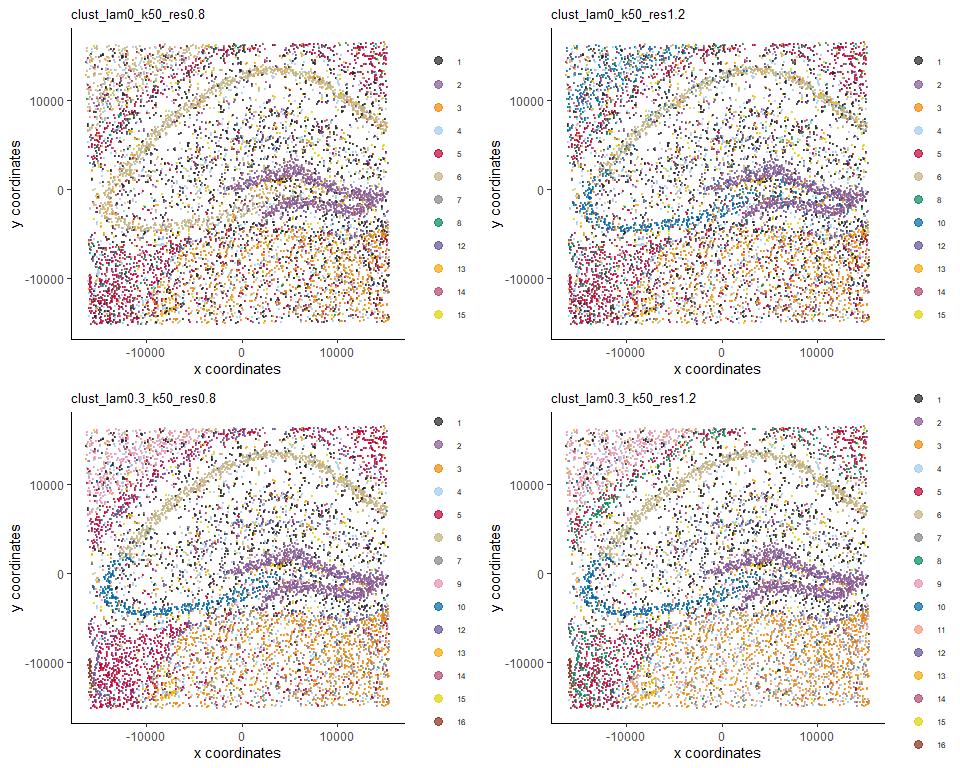

```r
plotSpatialFeatures(bank, by = clustnames, type = rep('discrete', 4),
                    nrow = 2, ncol = 2, main = clustnames, main.size = 10)
```

We visualise the differences between clustering with `lam=0` and `lam=0.3` more finely by splitting the clusters with `ggplot2::facet_wrap`:

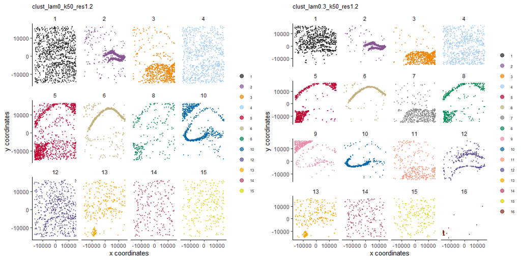

```r
p1 <- plotSpatial(bank, by = clustnames[2], type = 'discrete',
            main = clustnames[2], main.size = 10, pt.size = 0.1) + facet_wrap(~ feature)

p2 <- plotSpatial(bank, by = clustnames[4], type = 'discrete',
            main = clustnames[4], main.size = 10, pt.size = 0.1) + facet_wrap(~ feature)

grid.arrange(p1, p2, ncol = 2)
```